# Risk Factor Analysis

## Outcome Variable

**Outcome Variable:** sstunted

## Predictor Variables

**Intervention Variable:** gagebrth

**Adjustment Set:**

- arm
- sex
- W_mage
- meducyrs
- feducyrs
- hhwealth_quart
- single
- brthmon
- W_parity
- delta_W_mage
- delta_meducyrs
- delta_feducyrs
- delta_hhwealth_quart
- delta_single
- delta_brthmon
- delta_W_parity

## Stratifying Variables

The analysis was stratified on these variable(s):

- agecat
- studyid
- country

## Data Summary

| agecat | studyid | country | gagebrth | sstunted | n_cell | n |
| --- | --- | --- | --- | --- | --- | --- |
| Birth | ki1000108-CMC-V-BCS-2002 | INDIA | Full or late term | 0 | 54 | 90 |
| Birth | ki1000108-CMC-V-BCS-2002 | INDIA | Full or late term | 1 | 3 | 90 |
| Birth | ki1000108-CMC-V-BCS-2002 | INDIA | Preterm | 0 | 10 | 90 |
| Birth | ki1000108-CMC-V-BCS-2002 | INDIA | Preterm | 1 | 0 | 90 |
| Birth | ki1000108-CMC-V-BCS-2002 | INDIA | Early term | 0 | 23 | 90 |
| Birth | ki1000108-CMC-V-BCS-2002 | INDIA | Early term | 1 | 0 | 90 |
| Birth | ki1000108-IRC | INDIA | Full or late term | 0 | 228 | 369 |
| Birth | ki1000108-IRC | INDIA | Full or late term | 1 | 10 | 369 |
| Birth | ki1000108-IRC | INDIA | Preterm | 0 | 33 | 369 |
| Birth | ki1000108-IRC | INDIA | Preterm | 1 | 3 | 369 |
| Birth | ki1000108-IRC | INDIA | Early term | 0 | 93 | 369 |
| Birth | ki1000108-IRC | INDIA | Early term | 1 | 2 | 369 |
| Birth | ki1000109-EE | PAKISTAN | Full or late term | 0 | 0 | 2 |
| Birth | ki1000109-EE | PAKISTAN | Full or late term | 1 | 0 | 2 |
| Birth | ki1000109-EE | PAKISTAN | Preterm | 0 | 1 | 2 |
| Birth | ki1000109-EE | PAKISTAN | Preterm | 1 | 0 | 2 |
| Birth | ki1000109-EE | PAKISTAN | Early term | 0 | 1 | 2 |
| Birth | ki1000109-EE | PAKISTAN | Early term | 1 | 0 | 2 |
| Birth | ki1000304b-SAS-CompFeed | INDIA | Full or late term | 0 | 1 | 187 |
| Birth | ki1000304b-SAS-CompFeed | INDIA | Full or late term | 1 | 0 | 187 |
| Birth | ki1000304b-SAS-CompFeed | INDIA | Preterm | 0 | 161 | 187 |
| Birth | ki1000304b-SAS-CompFeed | INDIA | Preterm | 1 | 10 | 187 |
| Birth | ki1000304b-SAS-CompFeed | INDIA | Early term | 0 | 14 | 187 |
| Birth | ki1000304b-SAS-CompFeed | INDIA | Early term | 1 | 1 | 187 |
| Birth | ki1017093c-NIH-Crypto | BANGLADESH | Full or late term | 0 | 7 | 27 |
| Birth | ki1017093c-NIH-Crypto | BANGLADESH | Full or late term | 1 | 0 | 27 |
| Birth | ki1017093c-NIH-Crypto | BANGLADESH | Preterm | 0 | 5 | 27 |
| Birth | ki1017093c-NIH-Crypto | BANGLADESH | Preterm | 1 | 0 | 27 |
| Birth | ki1017093c-NIH-Crypto | BANGLADESH | Early term | 0 | 14 | 27 |
| Birth | ki1017093c-NIH-Crypto | BANGLADESH | Early term | 1 | 1 | 27 |

[output cut: 168 more lines]

The following strata were considered:

- agecat: 24 months, studyid: ki1000108-CMC-V-BCS-2002, country: INDIA
- agecat: 24 months, studyid: ki1000108-IRC, country: INDIA
- agecat: 24 months, studyid: ki1017093c-NIH-Crypto, country: BANGLADESH
- agecat: 24 months, studyid: ki1066203-TanzaniaChild2, country: TANZANIA, UNITED REPUBLIC OF
- agecat: 24 months, studyid: ki1101329-Keneba, country: GAMBIA
- agecat: 24 months, studyid: ki1119695-PROBIT, country: BELARUS
- agecat: 24 months, studyid: ki1135781-COHORTS, country: GUATEMALA
- agecat: 24 months, studyid: ki1135781-COHORTS, country: INDIA
- agecat: 24 months, studyid: ki1135781-COHORTS, country: PHILIPPINES
- agecat: 24 months, studyid: kiGH5241-JiVitA-3, country: BANGLADESH
- agecat: 6 months, studyid: ki1000108-CMC-V-BCS-2002, country: INDIA
- agecat: 6 months, studyid: ki1000108-IRC, country: INDIA
- agecat: 6 months, studyid: ki1000109-EE, country: PAKISTAN
- agecat: 6 months, studyid: ki1000304b-SAS-CompFeed, country: INDIA
- agecat: 6 months, studyid: ki1017093c-NIH-Crypto, country: BANGLADESH
- agecat: 6 months, studyid: ki1066203-TanzaniaChild2, country: TANZANIA, UNITED REPUBLIC OF
- agecat: 6 months, studyid: ki1101329-Keneba, country: GAMBIA
- agecat: 6 months, studyid: ki1119695-PROBIT, country: BELARUS
- agecat: 6 months, studyid: ki1135781-COHORTS, country: GUATEMALA
- agecat: 6 months, studyid: ki1135781-COHORTS, country: INDIA
- agecat: 6 months, studyid: ki1135781-COHORTS, country: PHILIPPINES
- agecat: 6 months, studyid: kiGH5241-JiVitA-3, country: BANGLADESH
- agecat: Birth, studyid: ki1000108-CMC-V-BCS-2002, country: INDIA
- agecat: Birth, studyid: ki1000108-IRC, country: INDIA
- agecat: Birth, studyid: ki1000109-EE, country: PAKISTAN
- agecat: Birth, studyid: ki1000304b-SAS-CompFeed, country: INDIA
- agecat: Birth, studyid: ki1017093c-NIH-Crypto, country: BANGLADESH
- agecat: Birth, studyid: ki1101329-Keneba, country: GAMBIA
- agecat: Birth, studyid: ki1119695-PROBIT, country: BELARUS
- agecat: Birth, studyid: ki1135781-COHORTS, country: GUATEMALA
- agecat: Birth, studyid: ki1135781-COHORTS, country: INDIA
- agecat: Birth, studyid: ki1135781-COHORTS, country: PHILIPPINES
- agecat: Birth, studyid: kiGH5241-JiVitA-3, country: BANGLADESH

### Dropped Strata

Some strata were dropped due to rare outcomes:

- agecat: Birth, studyid: ki1000108-CMC-V-BCS-2002, country: INDIA
- agecat: Birth, studyid: ki1000108-IRC, country: INDIA
- agecat: Birth, studyid: ki1000109-EE, country: PAKISTAN
- agecat: Birth, studyid: ki1000304b-SAS-CompFeed, country: INDIA
- agecat: Birth, studyid: ki1017093c-NIH-Crypto, country: BANGLADESH
- agecat: Birth, studyid: ki1119695-PROBIT, country: BELARUS
- agecat: Birth, studyid: ki1135781-COHORTS, country: GUATEMALA
- agecat: Birth, studyid: ki1135781-COHORTS, country: PHILIPPINES
- agecat: 6 months, studyid: ki1000108-IRC, country: INDIA
- agecat: 6 months, studyid: ki1000109-EE, country: PAKISTAN
- agecat: 6 months, studyid: ki1000304b-SAS-CompFeed, country: INDIA
- agecat: 6 months, studyid: ki1017093c-NIH-Crypto, country: BANGLADESH
- agecat: 6 months, studyid: ki1066203-TanzaniaChild2, country: TANZANIA, UNITED REPUBLIC OF
- agecat: 6 months, studyid: ki1101329-Keneba, country: GAMBIA
- agecat: 24 months, studyid: ki1017093c-NIH-Crypto, country: BANGLADESH
- agecat: 24 months, studyid: ki1066203-TanzaniaChild2, country: TANZANIA, UNITED REPUBLIC OF

## Methods Detail

We’re interested in the causal parameters $E[Y_a]$ for all values of $a \in \mathcal{A}$. These parameters represent the mean outcome if, possibly contrary to fact, we intervened to set all units to have $A=a$. Under the randomization and positivity assumptions, these are identified by the statistical parameters $\psi_a=E_W[E_{Y|A,W}(Y|A=a,W)]$. In addition, we’re interested in the mean of $Y$, $E[Y]$ under no intervention (the observed mean). We will estimate these parameters by using SuperLearner to fit the relevant likelihood factors – $E_{Y|A,W}(Y|A=a,W)$ and $p(A=a|W)$, and then updating our likelihood fit using a joint TMLE.

For unadjusted analyses ($W=\{\}$), initial likelihoods were estimated using Lrnr_glm to estimate the simple $E(Y|A)$ and Lrnr_mean to estimate $p(A)$. For adjusted analyses, a small library containing Lrnr_glmnet, Lrnr_xgboost, and Lrnr_mean was used.

Having estimated these parameters, we will then use the delta method to estimate relative risks and attributable risks relative to a prespecified baseline level of $A$.

# Results Detail

## Results Plots

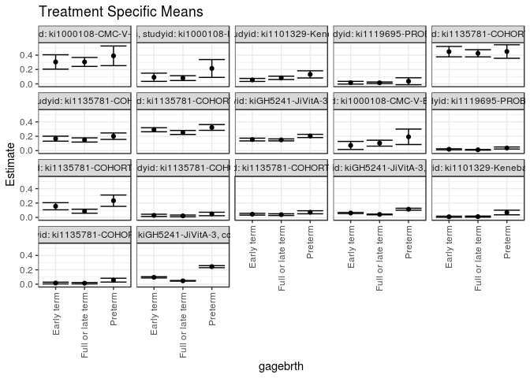

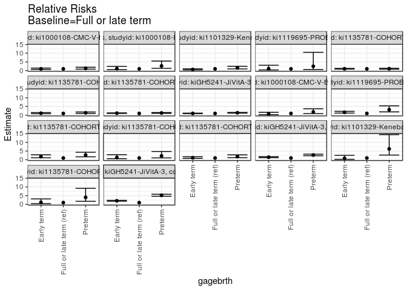

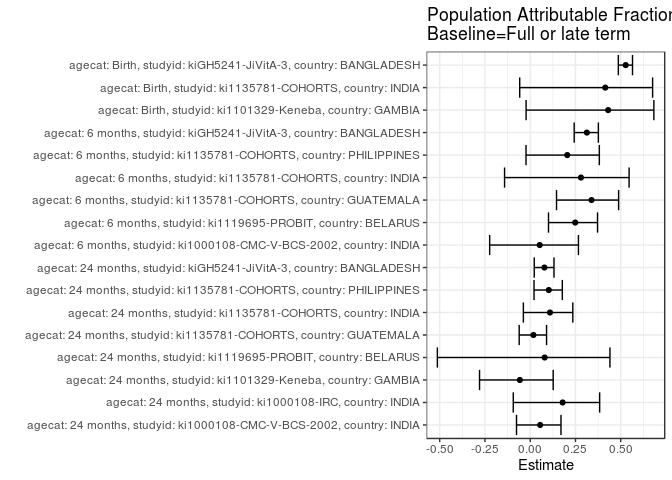

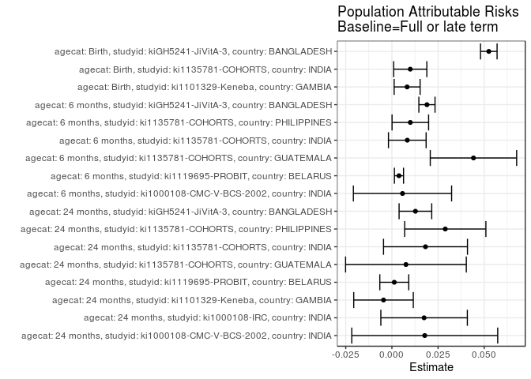

## Results Table

### Parameter: TSM

| agecat | studyid | country | intervention_level | baseline_level | estimate | ci_lower | ci_upper |
| --- | --- | --- | --- | --- | --- | --- | --- |
| Birth | ki1101329-Keneba | GAMBIA | Full or late term | NA | 0.0108992 | 0.0033854 | 0.0184130 |
| Birth | ki1101329-Keneba | GAMBIA | Preterm | NA | 0.0680851 | 0.0358691 | 0.1003011 |
| Birth | ki1101329-Keneba | GAMBIA | Early term | NA | 0.0091575 | 0.0011649 | 0.0171501 |
| Birth | ki1135781-COHORTS | INDIA | Full or late term | NA | 0.0140351 | 0.0043742 | 0.0236960 |
| Birth | ki1135781-COHORTS | INDIA | Preterm | NA | 0.0561404 | 0.0294051 | 0.0828756 |
| Birth | ki1135781-COHORTS | INDIA | Early term | NA | 0.0159817 | 0.0042330 | 0.0277305 |
| Birth | kiGH5241-JiVitA-3 | BANGLADESH | Full or late term | NA | 0.0470107 | 0.0424836 | 0.0515377 |
| Birth | kiGH5241-JiVitA-3 | BANGLADESH | Preterm | NA | 0.2439381 | 0.2297867 | 0.2580895 |
| Birth | kiGH5241-JiVitA-3 | BANGLADESH | Early term | NA | 0.0955275 | 0.0868178 | 0.1042372 |
| 6 months | ki1000108-CMC-V-BCS-2002 | INDIA | Full or late term | NA | 0.1037736 | 0.0626625 | 0.1448847 |
| 6 months | ki1000108-CMC-V-BCS-2002 | INDIA | Preterm | NA | 0.1923077 | 0.0850337 | 0.2995817 |
| 6 months | ki1000108-CMC-V-BCS-2002 | INDIA | Early term | NA | 0.0722892 | 0.0164963 | 0.1280820 |
| 6 months | ki1119695-PROBIT | BELARUS | Full or late term | NA | 0.0115862 | 0.0070229 | 0.0161495 |
| 6 months | ki1119695-PROBIT | BELARUS | Preterm | NA | 0.0368110 | 0.0225061 | 0.0511159 |
| 6 months | ki1119695-PROBIT | BELARUS | Early term | NA | 0.0190153 | 0.0116257 | 0.0264048 |
| 6 months | ki1135781-COHORTS | GUATEMALA | Full or late term | NA | 0.0862609 | 0.0583212 | 0.1142006 |
| 6 months | ki1135781-COHORTS | GUATEMALA | Preterm | NA | 0.2326468 | 0.1538056 | 0.3114879 |
| 6 months | ki1135781-COHORTS | GUATEMALA | Early term | NA | 0.1552760 | 0.1057623 | 0.2047898 |
| 6 months | ki1135781-COHORTS | INDIA | Full or late term | NA | 0.0213955 | 0.0095072 | 0.0332838 |
| 6 months | ki1135781-COHORTS | INDIA | Preterm | NA | 0.0481365 | 0.0240757 | 0.0721972 |
| 6 months | ki1135781-COHORTS | INDIA | Early term | NA | 0.0286858 | 0.0132411 | 0.0441304 |
| 6 months | ki1135781-COHORTS | PHILIPPINES | Full or late term | NA | 0.0387733 | 0.0270300 | 0.0505166 |
| 6 months | ki1135781-COHORTS | PHILIPPINES | Preterm | NA | 0.0715170 | 0.0504717 | 0.0925623 |
| 6 months | ki1135781-COHORTS | PHILIPPINES | Early term | NA | 0.0444088 | 0.0321898 | 0.0566279 |
| 6 months | kiGH5241-JiVitA-3 | BANGLADESH | Full or late term | NA | 0.0416688 | 0.0366821 | 0.0466554 |
| 6 months | kiGH5241-JiVitA-3 | BANGLADESH | Preterm | NA | 0.1135440 | 0.0998097 | 0.1272782 |
| 6 months | kiGH5241-JiVitA-3 | BANGLADESH | Early term | NA | 0.0611534 | 0.0525527 | 0.0697540 |
| 24 months | ki1000108-CMC-V-BCS-2002 | INDIA | Full or late term | NA | 0.3050767 | 0.2429086 | 0.3672448 |
| 24 months | ki1000108-CMC-V-BCS-2002 | INDIA | Preterm | NA | 0.3900393 | 0.2531984 | 0.5268801 |
| 24 months | ki1000108-CMC-V-BCS-2002 | INDIA | Early term | NA | 0.3048453 | 0.2048394 | 0.4048513 |
| 24 months | ki1000108-IRC | INDIA | Full or late term | NA | 0.0800000 | 0.0463276 | 0.1136724 |
| 24 months | ki1000108-IRC | INDIA | Preterm | NA | 0.2142857 | 0.0900319 | 0.3385396 |
| 24 months | ki1000108-IRC | INDIA | Early term | NA | 0.0918367 | 0.0345858 | 0.1490877 |
| 24 months | ki1101329-Keneba | GAMBIA | Full or late term | NA | 0.0841320 | 0.0609380 | 0.1073259 |
| 24 months | ki1101329-Keneba | GAMBIA | Preterm | NA | 0.1319236 | 0.0821343 | 0.1817128 |
| 24 months | ki1101329-Keneba | GAMBIA | Early term | NA | 0.0546340 | 0.0336441 | 0.0756240 |
| 24 months | ki1119695-PROBIT | BELARUS | Full or late term | NA | 0.0148221 | 0.0038188 | 0.0258255 |
| 24 months | ki1119695-PROBIT | BELARUS | Preterm | NA | 0.0364964 | -0.0116126 | 0.0846053 |
| 24 months | ki1119695-PROBIT | BELARUS | Early term | NA | 0.0160085 | -0.0030877 | 0.0351047 |
| 24 months | ki1135781-COHORTS | GUATEMALA | Full or late term | NA | 0.4252746 | 0.3754365 | 0.4751127 |
| 24 months | ki1135781-COHORTS | GUATEMALA | Preterm | NA | 0.4500278 | 0.3560391 | 0.5440164 |
| 24 months | ki1135781-COHORTS | GUATEMALA | Early term | NA | 0.4482744 | 0.3761088 | 0.5204400 |
| 24 months | ki1135781-COHORTS | INDIA | Full or late term | NA | 0.1484745 | 0.1192577 | 0.1776913 |
| 24 months | ki1135781-COHORTS | INDIA | Preterm | NA | 0.2013207 | 0.1564193 | 0.2462222 |
| 24 months | ki1135781-COHORTS | INDIA | Early term | NA | 0.1665117 | 0.1318740 | 0.2011494 |
| 24 months | ki1135781-COHORTS | PHILIPPINES | Full or late term | NA | 0.2528600 | 0.2251296 | 0.2805903 |
| 24 months | ki1135781-COHORTS | PHILIPPINES | Preterm | NA | 0.3225251 | 0.2825069 | 0.3625433 |
| 24 months | ki1135781-COHORTS | PHILIPPINES | Early term | NA | 0.2906896 | 0.2625038 | 0.3188753 |
| 24 months | kiGH5241-JiVitA-3 | BANGLADESH | Full or late term | NA | 0.1495992 | 0.1361191 | 0.1630794 |
| 24 months | kiGH5241-JiVitA-3 | BANGLADESH | Preterm | NA | 0.2044219 | 0.1818153 | 0.2270285 |
| 24 months | kiGH5241-JiVitA-3 | BANGLADESH | Early term | NA | 0.1543790 | 0.1353509 | 0.1734072 |

### Parameter: E(Y)

| agecat | studyid | country | intervention_level | baseline_level | estimate | ci_lower | ci_upper |
| --- | --- | --- | --- | --- | --- | --- | --- |
| Birth | ki1101329-Keneba | GAMBIA | NA | NA | 0.0191419 | 0.0122398 | 0.0260440 |
| Birth | ki1135781-COHORTS | INDIA | NA | NA | 0.0239753 | 0.0156340 | 0.0323165 |
| Birth | kiGH5241-JiVitA-3 | BANGLADESH | NA | NA | 0.0994901 | 0.0949359 | 0.1040443 |
| 6 months | ki1000108-CMC-V-BCS-2002 | INDIA | NA | NA | 0.1095101 | 0.0766059 | 0.1424143 |
| 6 months | ki1119695-PROBIT | BELARUS | NA | NA | 0.0154178 | 0.0100323 | 0.0208033 |
| 6 months | ki1135781-COHORTS | GUATEMALA | NA | NA | 0.1304348 | 0.1056973 | 0.1551723 |
| 6 months | ki1135781-COHORTS | INDIA | NA | NA | 0.0297256 | 0.0205326 | 0.0389187 |
| 6 months | ki1135781-COHORTS | PHILIPPINES | NA | NA | 0.0487533 | 0.0406091 | 0.0568974 |
| 6 months | kiGH5241-JiVitA-3 | BANGLADESH | NA | NA | 0.0606473 | 0.0560424 | 0.0652522 |
| 24 months | ki1000108-CMC-V-BCS-2002 | INDIA | NA | NA | 0.3228571 | 0.2738024 | 0.3719119 |
| 24 months | ki1000108-IRC | INDIA | NA | NA | 0.0974359 | 0.0679665 | 0.1269053 |
| 24 months | ki1101329-Keneba | GAMBIA | NA | NA | 0.0795848 | 0.0639762 | 0.0951934 |
| 24 months | ki1119695-PROBIT | BELARUS | NA | NA | 0.0161090 | 0.0034156 | 0.0288025 |
| 24 months | ki1135781-COHORTS | GUATEMALA | NA | NA | 0.4328808 | 0.3951375 | 0.4706242 |
| 24 months | ki1135781-COHORTS | INDIA | NA | NA | 0.1666667 | 0.1464624 | 0.1868710 |
| 24 months | ki1135781-COHORTS | PHILIPPINES | NA | NA | 0.2817657 | 0.2638535 | 0.2996779 |
| 24 months | kiGH5241-JiVitA-3 | BANGLADESH | NA | NA | 0.1623287 | 0.1518640 | 0.1727933 |

### Parameter: RR

| agecat | studyid | country | intervention_level | baseline_level | estimate | ci_lower | ci_upper |
| --- | --- | --- | --- | --- | --- | --- | --- |
| Birth | ki1101329-Keneba | GAMBIA | Full or late term | Full or late term | 1.0000000 | 1.0000000 | 1.000000 |
| Birth | ki1101329-Keneba | GAMBIA | Preterm | Full or late term | 6.2468085 | 2.7072028 | 14.414368 |
| Birth | ki1101329-Keneba | GAMBIA | Early term | Full or late term | 0.8402015 | 0.2762834 | 2.555125 |
| Birth | ki1135781-COHORTS | INDIA | Full or late term | Full or late term | 1.0000000 | 1.0000000 | 1.000000 |
| Birth | ki1135781-COHORTS | INDIA | Preterm | Full or late term | 4.0000000 | 1.7320013 | 9.237869 |
| Birth | ki1135781-COHORTS | INDIA | Early term | Full or late term | 1.1386986 | 0.4159430 | 3.117338 |
| Birth | kiGH5241-JiVitA-3 | BANGLADESH | Full or late term | Full or late term | 1.0000000 | 1.0000000 | 1.000000 |
| Birth | kiGH5241-JiVitA-3 | BANGLADESH | Preterm | Full or late term | 5.1889960 | 4.6261903 | 5.820271 |
| Birth | kiGH5241-JiVitA-3 | BANGLADESH | Early term | Full or late term | 2.0320392 | 1.7836483 | 2.315021 |
| 6 months | ki1000108-CMC-V-BCS-2002 | INDIA | Full or late term | Full or late term | 1.0000000 | 1.0000000 | 1.000000 |
| 6 months | ki1000108-CMC-V-BCS-2002 | INDIA | Preterm | Full or late term | 1.8531469 | 0.9349126 | 3.673234 |
| 6 months | ki1000108-CMC-V-BCS-2002 | INDIA | Early term | Full or late term | 0.6966046 | 0.2925632 | 1.658643 |
| 6 months | ki1119695-PROBIT | BELARUS | Full or late term | Full or late term | 1.0000000 | 1.0000000 | 1.000000 |
| 6 months | ki1119695-PROBIT | BELARUS | Preterm | Full or late term | 3.1771445 | 1.8894108 | 5.342537 |
| 6 months | ki1119695-PROBIT | BELARUS | Early term | Full or late term | 1.6412018 | 1.2222296 | 2.203795 |
| 6 months | ki1135781-COHORTS | GUATEMALA | Full or late term | Full or late term | 1.0000000 | 1.0000000 | 1.000000 |
| 6 months | ki1135781-COHORTS | GUATEMALA | Preterm | Full or late term | 2.6970142 | 1.6873167 | 4.310919 |
| 6 months | ki1135781-COHORTS | GUATEMALA | Early term | Full or late term | 1.8000752 | 1.1422804 | 2.836668 |
| 6 months | ki1135781-COHORTS | INDIA | Full or late term | Full or late term | 1.0000000 | 1.0000000 | 1.000000 |
| 6 months | ki1135781-COHORTS | INDIA | Preterm | Full or late term | 2.2498397 | 1.0663949 | 4.746627 |
| 6 months | ki1135781-COHORTS | INDIA | Early term | Full or late term | 1.3407374 | 0.6184962 | 2.906366 |
| 6 months | ki1135781-COHORTS | PHILIPPINES | Full or late term | Full or late term | 1.0000000 | 1.0000000 | 1.000000 |
| 6 months | ki1135781-COHORTS | PHILIPPINES | Preterm | Full or late term | 1.8444910 | 1.2091150 | 2.813750 |
| 6 months | ki1135781-COHORTS | PHILIPPINES | Early term | Full or late term | 1.1453456 | 0.7611191 | 1.723536 |
| 6 months | kiGH5241-JiVitA-3 | BANGLADESH | Full or late term | Full or late term | 1.0000000 | 1.0000000 | 1.000000 |
| 6 months | kiGH5241-JiVitA-3 | BANGLADESH | Preterm | Full or late term | 2.7249189 | 2.3099601 | 3.214421 |
| 6 months | kiGH5241-JiVitA-3 | BANGLADESH | Early term | Full or late term | 1.4676071 | 1.2185781 | 1.767528 |
| 24 months | ki1000108-CMC-V-BCS-2002 | INDIA | Full or late term | Full or late term | 1.0000000 | 1.0000000 | 1.000000 |
| 24 months | ki1000108-CMC-V-BCS-2002 | INDIA | Preterm | Full or late term | 1.2784959 | 0.8512821 | 1.920106 |
| 24 months | ki1000108-CMC-V-BCS-2002 | INDIA | Early term | Full or late term | 0.9992417 | 0.6797016 | 1.469003 |
| 24 months | ki1000108-IRC | INDIA | Full or late term | Full or late term | 1.0000000 | 1.0000000 | 1.000000 |
| 24 months | ki1000108-IRC | INDIA | Preterm | Full or late term | 2.6785714 | 1.3083567 | 5.483783 |
| 24 months | ki1000108-IRC | INDIA | Early term | Full or late term | 1.1479592 | 0.5410719 | 2.435555 |
| 24 months | ki1101329-Keneba | GAMBIA | Full or late term | Full or late term | 1.0000000 | 1.0000000 | 1.000000 |
| 24 months | ki1101329-Keneba | GAMBIA | Preterm | Full or late term | 1.5680552 | 0.9841780 | 2.498325 |
| 24 months | ki1101329-Keneba | GAMBIA | Early term | Full or late term | 0.6493850 | 0.4053240 | 1.040405 |
| 24 months | ki1119695-PROBIT | BELARUS | Full or late term | Full or late term | 1.0000000 | 1.0000000 | 1.000000 |
| 24 months | ki1119695-PROBIT | BELARUS | Preterm | Full or late term | 2.4622871 | 0.5762612 | 10.521023 |
| 24 months | ki1119695-PROBIT | BELARUS | Early term | Full or late term | 1.0800427 | 0.3773256 | 3.091474 |
| 24 months | ki1135781-COHORTS | GUATEMALA | Full or late term | Full or late term | 1.0000000 | 1.0000000 | 1.000000 |
| 24 months | ki1135781-COHORTS | GUATEMALA | Preterm | Full or late term | 1.0582052 | 0.8336961 | 1.343173 |
| 24 months | ki1135781-COHORTS | GUATEMALA | Early term | Full or late term | 1.0540822 | 0.8648843 | 1.284668 |
| 24 months | ki1135781-COHORTS | INDIA | Full or late term | Full or late term | 1.0000000 | 1.0000000 | 1.000000 |
| 24 months | ki1135781-COHORTS | INDIA | Preterm | Full or late term | 1.3559281 | 1.0080249 | 1.823904 |
| 24 months | ki1135781-COHORTS | INDIA | Early term | Full or late term | 1.1214836 | 0.8435975 | 1.490907 |
| 24 months | ki1135781-COHORTS | PHILIPPINES | Full or late term | Full or late term | 1.0000000 | 1.0000000 | 1.000000 |
| 24 months | ki1135781-COHORTS | PHILIPPINES | Preterm | Full or late term | 1.2755088 | 1.0816356 | 1.504132 |
| 24 months | ki1135781-COHORTS | PHILIPPINES | Early term | Full or late term | 1.1496070 | 0.9939792 | 1.329601 |
| 24 months | kiGH5241-JiVitA-3 | BANGLADESH | Full or late term | Full or late term | 1.0000000 | 1.0000000 | 1.000000 |
| 24 months | kiGH5241-JiVitA-3 | BANGLADESH | Preterm | Full or late term | 1.3664636 | 1.1904164 | 1.568546 |
| 24 months | kiGH5241-JiVitA-3 | BANGLADESH | Early term | Full or late term | 1.0319509 | 0.8926951 | 1.192930 |

### Parameter: PAR

| agecat | studyid | country | intervention_level | baseline_level | estimate | ci_lower | ci_upper |
| --- | --- | --- | --- | --- | --- | --- | --- |
| Birth | ki1101329-Keneba | GAMBIA | Full or late term | NA | 0.0082427 | 0.0012149 | 0.0152706 |
| Birth | ki1135781-COHORTS | INDIA | Full or late term | NA | 0.0099402 | 0.0009613 | 0.0189190 |
| Birth | kiGH5241-JiVitA-3 | BANGLADESH | Full or late term | NA | 0.0524794 | 0.0479948 | 0.0569640 |
| 6 months | ki1000108-CMC-V-BCS-2002 | INDIA | Full or late term | NA | 0.0057365 | -0.0208651 | 0.0323381 |
| 6 months | ki1119695-PROBIT | BELARUS | Full or late term | NA | 0.0038316 | 0.0013699 | 0.0062933 |
| 6 months | ki1135781-COHORTS | GUATEMALA | Full or late term | NA | 0.0441739 | 0.0207742 | 0.0675736 |
| 6 months | ki1135781-COHORTS | INDIA | Full or late term | NA | 0.0083301 | -0.0018684 | 0.0185286 |
| 6 months | ki1135781-COHORTS | PHILIPPINES | Full or late term | NA | 0.0099800 | 0.0000777 | 0.0198822 |
| 6 months | kiGH5241-JiVitA-3 | BANGLADESH | Full or late term | NA | 0.0189786 | 0.0146037 | 0.0233534 |
| 24 months | ki1000108-CMC-V-BCS-2002 | INDIA | Full or late term | NA | 0.0177805 | -0.0217410 | 0.0573019 |
| 24 months | ki1000108-IRC | INDIA | Full or late term | NA | 0.0174359 | -0.0059874 | 0.0408591 |
| 24 months | ki1101329-Keneba | GAMBIA | Full or late term | NA | -0.0045472 | -0.0206738 | 0.0115794 |
| 24 months | ki1119695-PROBIT | BELARUS | Full or late term | NA | 0.0012869 | -0.0065493 | 0.0091231 |
| 24 months | ki1135781-COHORTS | GUATEMALA | Full or late term | NA | 0.0076063 | -0.0250857 | 0.0402983 |
| 24 months | ki1135781-COHORTS | INDIA | Full or late term | NA | 0.0181922 | -0.0045393 | 0.0409236 |
| 24 months | ki1135781-COHORTS | PHILIPPINES | Full or late term | NA | 0.0289057 | 0.0069084 | 0.0509030 |
| 24 months | kiGH5241-JiVitA-3 | BANGLADESH | Full or late term | NA | 0.0127294 | 0.0038886 | 0.0215703 |

### Parameter: PAF

| agecat | studyid | country | intervention_level | baseline_level | estimate | ci_lower | ci_upper |
| --- | --- | --- | --- | --- | --- | --- | --- |
| Birth | ki1101329-Keneba | GAMBIA | Full or late term | NA | 0.4306117 | -0.0227788 | 0.6830174 |
| Birth | ki1135781-COHORTS | INDIA | Full or late term | NA | 0.4146010 | -0.0580236 | 0.6761018 |
| Birth | kiGH5241-JiVitA-3 | BANGLADESH | Full or late term | NA | 0.5274840 | 0.4867047 | 0.5650235 |
| 6 months | ki1000108-CMC-V-BCS-2002 | INDIA | Full or late term | NA | 0.0523833 | -0.2240006 | 0.2663587 |
| 6 months | ki1119695-PROBIT | BELARUS | Full or late term | NA | 0.2485185 | 0.1010021 | 0.3718290 |
| 6 months | ki1135781-COHORTS | GUATEMALA | Full or late term | NA | 0.3386667 | 0.1453231 | 0.4882724 |
| 6 months | ki1135781-COHORTS | INDIA | Full or late term | NA | 0.2802332 | -0.1416763 | 0.5462250 |
| 6 months | ki1135781-COHORTS | PHILIPPINES | Full or late term | NA | 0.2047034 | -0.0231505 | 0.3818147 |
| 6 months | kiGH5241-JiVitA-3 | BANGLADESH | Full or late term | NA | 0.3129334 | 0.2428684 | 0.3765146 |
| 24 months | ki1000108-CMC-V-BCS-2002 | INDIA | Full or late term | NA | 0.0550723 | -0.0756936 | 0.1699416 |
| 24 months | ki1000108-IRC | INDIA | Full or late term | NA | 0.1789474 | -0.0935755 | 0.3835566 |
| 24 months | ki1101329-Keneba | GAMBIA | Full or late term | NA | -0.0571365 | -0.2799454 | 0.1268866 |
| 24 months | ki1119695-PROBIT | BELARUS | Full or late term | NA | 0.0798875 | -0.5128990 | 0.4404074 |
| 24 months | ki1135781-COHORTS | GUATEMALA | Full or late term | NA | 0.0175713 | -0.0609397 | 0.0902723 |
| 24 months | ki1135781-COHORTS | INDIA | Full or late term | NA | 0.1091531 | -0.0377804 | 0.2352831 |
| 24 months | ki1135781-COHORTS | PHILIPPINES | Full or late term | NA | 0.1025877 | 0.0210474 | 0.1773362 |
| 24 months | kiGH5241-JiVitA-3 | BANGLADESH | Full or late term | NA | 0.0784177 | 0.0222375 | 0.1313699 |